# Class 15: Pertussis mini-project

Audrey Ting Zhu (A16898668)

2024-11-19

## Background

Pertussis(whooping cough)is an highly infectious disease. The CDC tracks pertusssis cases numbers per year. Lets have a closer look at this data:

[CDC data](https://www.cdc.gov/pertussis/php/surveillance/pertussis-cases-by-year.html?CDC_AAref_Val=https://www.cdc.gov/pertussis/surv-reporting/cases-by-year.html)

> Q1. With the help of the R “addin” package datapasta assign the CDC pertussis case number data to a data frame called cdc and use ggplot to make a plot of cases numbers over time.

We will use the **datapasta** R package to “scrape” this data into R.

```r
cdc<-data.table::data.table(
                               Year = c(1922L,1923L,1924L,1925L,1926L,
                                        1927L,1928L,1929L,1930L,1931L,1932L,
                                        1933L,1934L,1935L,1936L,1937L,1938L,
                                        1939L,1940L,1941L,1942L,1943L,
                                        1944L,1945L,1946L,1947L,1948L,1949L,
                                        1950L,1951L,1952L,1953L,1954L,1955L,
                                        1956L,1957L,1958L,1959L,1960L,
                                        1961L,1962L,1963L,1964L,1965L,1966L,
                                        1967L,1968L,1969L,1970L,1971L,1972L,
                                        1973L,1974L,1975L,1976L,1977L,1978L,
                                        1979L,1980L,1981L,1982L,1983L,
                                        1984L,1985L,1986L,1987L,1988L,1989L,
                                        1990L,1991L,1992L,1993L,1994L,1995L,
                                        1996L,1997L,1998L,1999L,2000L,
                                        2001L,2002L,2003L,2004L,2005L,2006L,
                                        2007L,2008L,2009L,2010L,2011L,2012L,
                                        2013L,2014L,2015L,2016L,2017L,2018L,
                                        2019L,2020L,2021L,2022L,2024L),
       Cases = c(107473,164191,165418,152003,
                                        202210,181411,161799,197371,166914,
                                        172559,215343,179135,265269,180518,
                                        147237,214652,227319,103188,183866,
                                        222202,191383,191890,109873,133792,
                                        109860,156517,74715,69479,120718,68687,
                                        45030,37129,60886,62786,31732,28295,
                                        32148,40005,14809,11468,17749,
                                        17135,13005,6799,7717,9718,4810,3285,
                                        4249,3036,3287,1759,2402,1738,
                                        1010,2177,2063,1623,1730,1248,1895,
                                        2463,2276,3589,4195,2823,3450,4157,
                                        4570,2719,4083,6586,4617,5137,
                                        7796,6564,7405,7298,7867,7580,9771,
                                        11647,25827,25616,15632,10454,13278,
                                        16858,27550,18719,48277,28639,
                                        32971,20762,17972,18975,15609,18617,
                                        6124,2116,3044,23544)
     )
```

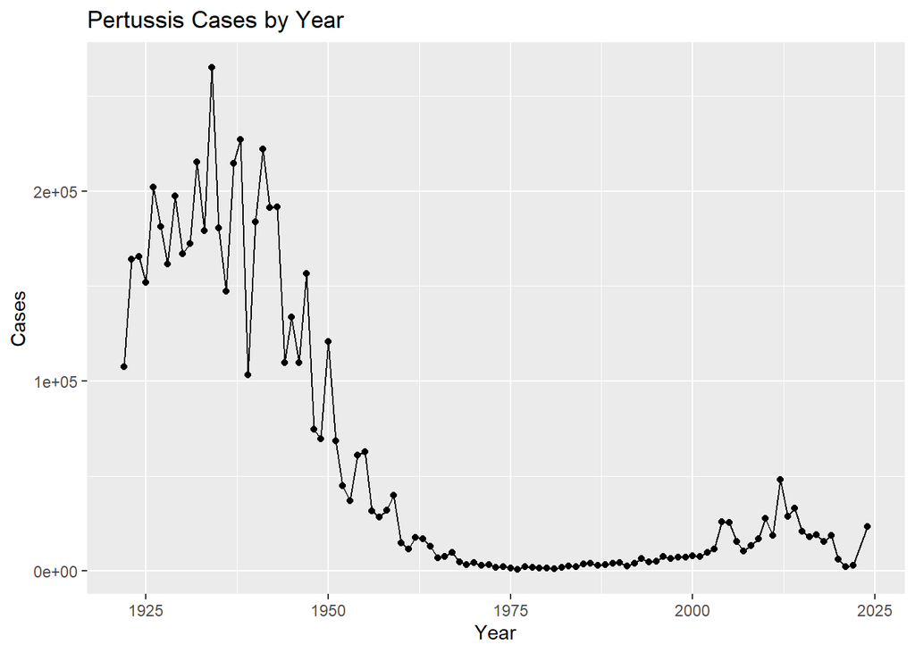

```r
library(ggplot2)
baseplot<-ggplot(cdc) +
  aes(Year,Cases) +
  geom_point() +
  geom_line() +
  labs(title="Pertussis Cases by Year")
baseplot
```

> Q2. Using the ggplot geom_vline() function add lines to your previous plot for the 1946 introduction of the wP vaccine and the 1996 switch to aP vaccine (see example in the hint below). What do you notice?

> Ans: The introduction of the wP vaccine leads to a great decrease in cases from around 200,000 prevaccine era to 1000 cases in 1976. We switched to aP vaccine in 1995. We then see a great increase in 2004 to around 26,000 cases.

Add some landmark developments as annotation:

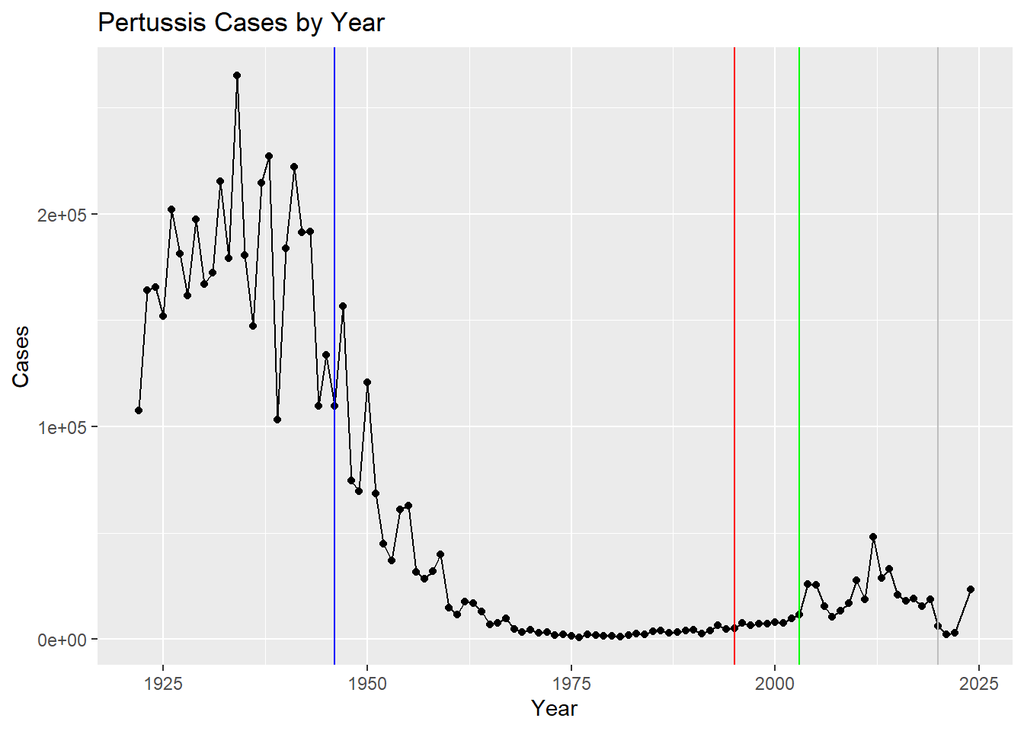

```r
baseplot+geom_vline(xintercept=1946,col="blue" )+geom_vline(xintercept=1995,col="red" )+geom_vline(xintercept=2020,col="grey" )+geom_vline(xintercept=2003,col="green" )
```

> Q3. Describe what happened after the introduction of the aP vaccine? Do you have a possible explanation for the observed trend? The specific date is labeled by the red line. There has been an increase in vaccine cases after the introduction of the aP vaccine. There could be better testing methods(PCR), increased vaccine hesitancy, bacterial evolution, and also that aP is just not as effective as wP.

The actual explanation is simply that aP does not provide better immunity compared to wP. This conclusion is generated by cross-country analysis. Scientist do not know why. That is the question.

**Key Question**: Why does the aP vaccine induced immunity wane faster than that of the wP vaccine?

## The CMI-PB(Computational Models of Immunity Pertusssis Boost) makes available lots of data about the immune response to Pertussis booster vaccine.

Critically, it tracks wP and aP individuals over time to see how their immune response changes.

CMI-PB make all their data freely availble via JSOB format tables from their database.

```r
library(jsonlite)
subject <- read_json("https://www.cmi-pb.org/api/subject", simplifyVector = TRUE)
head(subject, 3)
```

|  | subject_id | infancy_vac | biological_sex | ethnicity | race | year_of_birth | date_of_boost | dataset |
| --- | --- | --- | --- | --- | --- | --- | --- | --- |
| 1 | 1 | wP | Female | Not Hispanic or Latino | White | 1986-01-01 | 2016-09-12 | 2020_dataset |
| 2 | 2 | wP | Female | Not Hispanic or Latino | White | 1968-01-01 | 2019-01-28 | 2020_dataset |
| 3 | 3 | wP | Female | Unknown | White | 1983-01-01 | 2016-10-10 | 2020_dataset |

```r
nrow(subject)
```

```
## [1] 172
```

> Q4. How many aP and wP infancy vaccinated subjects are in the dataset?

```r
table(subject$infancy_vac)
```

```
##
## aP wP
## 87 85
```

> Q5. How many Male and Female subjects/patients are in the dataset?

```r
table(subject$biological_sex)
```

```
##
## Female   Male
##    112     60
```

> Q6. What is the breakdown of race and biological sex (e.g. number of Asian females, White males etc…)?

```r
table(subject$race,subject$biological_sex)
```

```
##
##                                             Female Male
##   American Indian/Alaska Native                  0    1
##   Asian                                         32   12
##   Black or African American                      2    3
##   More Than One Race                            15    4
##   Native Hawaiian or Other Pacific Islander      1    1
##   Unknown or Not Reported                       14    7
##   White                                         48   32
```

> Q8. Is this represntatitive of the US population? Ans:NO

Lets get more data from CMI-PE:

> Q9. Complete the code to join specimen and subject tables to make a new merged data frame containing all specimen records along with their associated subject details:

```r
library(jsonlite)
specimen<-read_json("https://www.cmi-pb.org/api/v5/specimen", simplifyVector=TRUE)
head(specimen)
```

|  | specimen_id | subject_id | actual_day_relative_to_boost | planned_day_relative_to_boost | specimen_type | visit |
| --- | --- | --- | --- | --- | --- | --- |
| 1 | 1 | 1 | -3 | 0 | Blood | 1 |
| 2 | 2 | 1 | 1 | 1 | Blood | 2 |
| 3 | 3 | 1 | 3 | 3 | Blood | 3 |
| 4 | 4 | 1 | 7 | 7 | Blood | 4 |
| 5 | 5 | 1 | 11 | 14 | Blood | 5 |
| 6 | 6 | 1 | 32 | 30 | Blood | 6 |

```r
library(dplyr)
meta <- inner_join(specimen, subject)
dim(meta)
```

```
## [1] 1503   13
```

```r
head(meta)
```

|  | specimen_id | subject_id | actual_day_relative_to_boost | planned_day_relative_to_boost | specimen_type | visit | infancy_vac | biological_sex | ethnicity | race | year_of_birth | date_of_boost | dataset |
| --- | --- | --- | --- | --- | --- | --- | --- | --- | --- | --- | --- | --- | --- |
| 1 | 1 | 1 | -3 | 0 | Blood | 1 | wP | Female | Not Hispanic or Latino | White | 1986-01-01 | 2016-09-12 | 2020_dataset |
| 2 | 2 | 1 | 1 | 1 | Blood | 2 | wP | Female | Not Hispanic or Latino | White | 1986-01-01 | 2016-09-12 | 2020_dataset |
| 3 | 3 | 1 | 3 | 3 | Blood | 3 | wP | Female | Not Hispanic or Latino | White | 1986-01-01 | 2016-09-12 | 2020_dataset |
| 4 | 4 | 1 | 7 | 7 | Blood | 4 | wP | Female | Not Hispanic or Latino | White | 1986-01-01 | 2016-09-12 | 2020_dataset |
| 5 | 5 | 1 | 11 | 14 | Blood | 5 | wP | Female | Not Hispanic or Latino | White | 1986-01-01 | 2016-09-12 | 2020_dataset |
| 6 | 6 | 1 | 32 | 30 | Blood | 6 | wP | Female | Not Hispanic or Latino | White | 1986-01-01 | 2016-09-12 | 2020_dataset |

```r
titer<-read_json("https://www.cmi-pb.org/api/v5/plasma_ab_titer",simplifyVector=TRUE)
head(titer)
```

|  | specimen_id | isotype | is_antigen_specific | antigen | MFI | MFI_normalised | unit | lower_limit_of_detection |
| --- | --- | --- | --- | --- | --- | --- | --- | --- |
| 1 | 1 | IgE | FALSE | Total | 1110.21154 | 2.493425 | UG/ML | 2.096133 |
| 2 | 1 | IgE | FALSE | Total | 2708.91616 | 2.493425 | IU/ML | 29.170000 |
| 3 | 1 | IgG | TRUE | PT | 68.56614 | 3.736992 | IU/ML | 0.530000 |
| 4 | 1 | IgG | TRUE | PRN | 332.12718 | 2.602350 | IU/ML | 6.205949 |
| 5 | 1 | IgG | TRUE | FHA | 1887.12263 | 34.050956 | IU/ML | 4.679535 |
| 6 | 1 | IgE | TRUE | ACT | 0.10000 | 1.000000 | IU/ML | 2.816431 |

> Q10. Now using the same procedure join meta with titer data so we can further analyze this data in terms of time of visit aP/wP, male/female etc.

```r
abdata <- inner_join(titer, meta)
dim(abdata)
```

```
## [1] 52576    20
```

> Q11. How many specimens (i.e. entries in abdata) do we have for each isotype?

```r
table(abdata$isotype)
```

```
##
##   IgE   IgG  IgG1  IgG2  IgG3  IgG4
##  6698  5389 10117 10124 10124 10124
```

> Q12. What are the different $dataset values in abdata and what do you notice about the number of rows for the most “recent” dataset?

```r
table(abdata$dataset)
```

```
##
## 2020_dataset 2021_dataset 2022_dataset 2023_dataset
##        31520         8085         7301         5670
```

> Ans: The most recent dataset has the lowest amount of rows.

```r
igg <- abdata %>% filter(isotype == "IgG")
head(igg)
```

|  | specimen_id | isotype | is_antigen_specific | antigen | MFI | MFI_normalised | unit | lower_limit_of_detection | subject_id | actual_day_relative_to_boost | planned_day_relative_to_boost | specimen_type | visit | infancy_vac | biological_sex | ethnicity | race | year_of_birth | date_of_boost | dataset |
| --- | --- | --- | --- | --- | --- | --- | --- | --- | --- | --- | --- | --- | --- | --- | --- | --- | --- | --- | --- | --- |
| 1 | 1 | IgG | TRUE | PT | 68.56614 | 3.736992 | IU/ML | 0.530000 | 1 | -3 | 0 | Blood | 1 | wP | Female | Not Hispanic or Latino | White | 1986-01-01 | 2016-09-12 | 2020_dataset |
| 2 | 1 | IgG | TRUE | PRN | 332.12718 | 2.602350 | IU/ML | 6.205949 | 1 | -3 | 0 | Blood | 1 | wP | Female | Not Hispanic or Latino | White | 1986-01-01 | 2016-09-12 | 2020_dataset |
| 3 | 1 | IgG | TRUE | FHA | 1887.12263 | 34.050956 | IU/ML | 4.679535 | 1 | -3 | 0 | Blood | 1 | wP | Female | Not Hispanic or Latino | White | 1986-01-01 | 2016-09-12 | 2020_dataset |
| 4 | 19 | IgG | TRUE | PT | 20.11607 | 1.096366 | IU/ML | 0.530000 | 3 | -3 | 0 | Blood | 1 | wP | Female | Unknown | White | 1983-01-01 | 2016-10-10 | 2020_dataset |
| 5 | 19 | IgG | TRUE | PRN | 976.67419 | 7.652635 | IU/ML | 6.205949 | 3 | -3 | 0 | Blood | 1 | wP | Female | Unknown | White | 1983-01-01 | 2016-10-10 | 2020_dataset |
| 6 | 19 | IgG | TRUE | FHA | 60.76626 | 1.096457 | IU/ML | 4.679535 | 3 | -3 | 0 | Blood | 1 | wP | Female | Unknown | White | 1983-01-01 | 2016-10-10 | 2020_dataset |

> Q13. Complete the following code to make a summary boxplot of Ab titer levels (MFI) for all antigens:

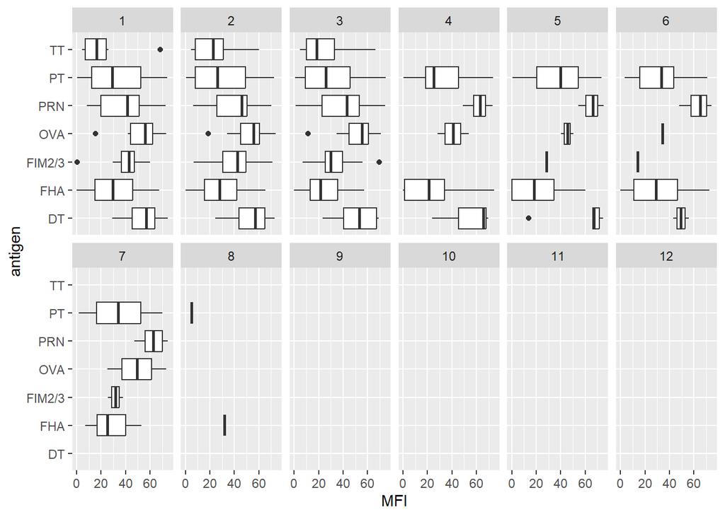

```r
library(ggplot2)
ggplot(igg) +
  aes(MFI, antigen) +
  geom_boxplot() +
    xlim(0,75) +
  facet_wrap(vars(visit), nrow=2)
```

> Q14. What antigens show differences in the level of IgG antibody titers recognizing them over time? Why these and not others?

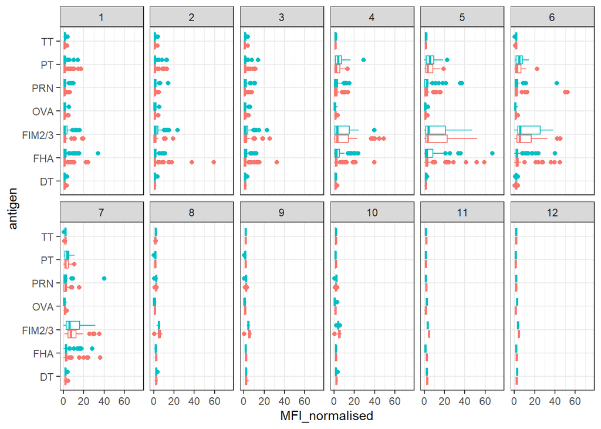

```r
ggplot(igg) +
  aes(MFI_normalised, antigen, col=infancy_vac ) +
  geom_boxplot(show.legend = FALSE) +
  facet_wrap(vars(visit), nrow=2) +
  xlim(0,75) +
  theme_bw()
```

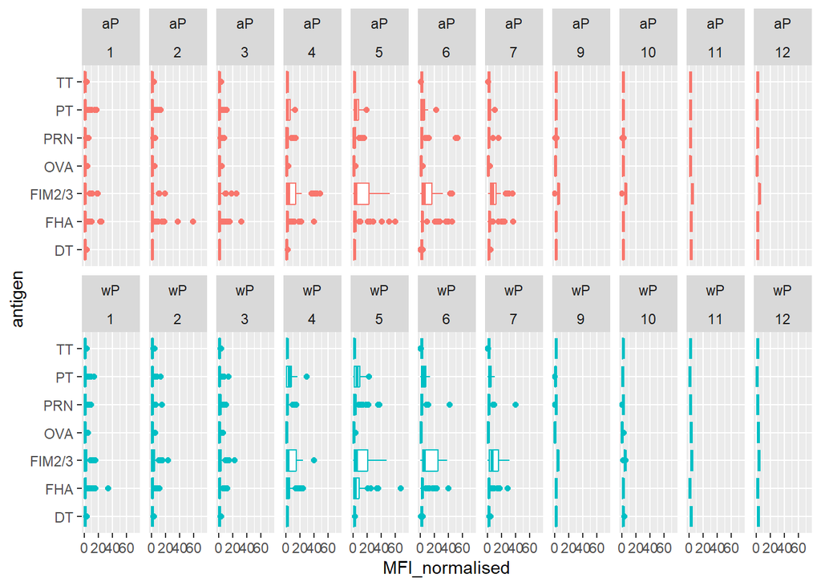

```r
igg %>% filter(visit != 8) %>%
ggplot() +
  aes(MFI_normalised, antigen, col=infancy_vac ) +
  geom_boxplot(show.legend = FALSE) +
  xlim(0,75) +
  facet_wrap(vars(infancy_vac, visit), nrow=2)
```

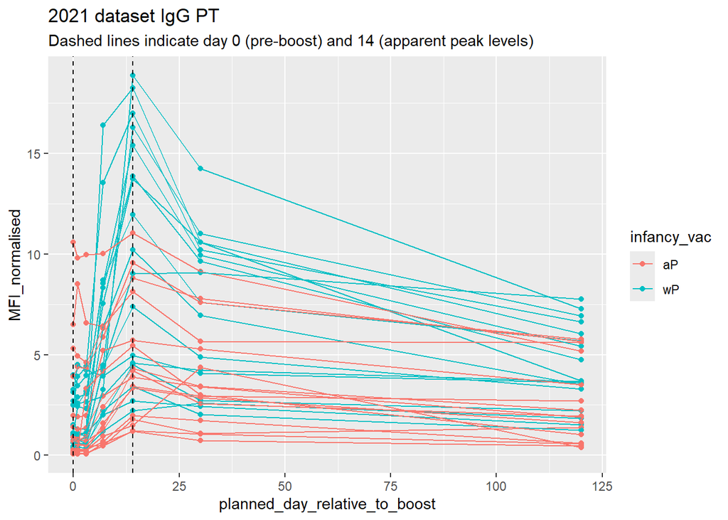

```r
abdata.21 <- abdata %>% filter(dataset == "2021_dataset")

abdata.21 %>%
  filter(isotype == "IgG",  antigen == "PT") %>%
  ggplot() +
    aes(x=planned_day_relative_to_boost,
        y=MFI_normalised,
        col=infancy_vac,
        group=subject_id) +
    geom_point() +
    geom_line() +
    geom_vline(xintercept=0, linetype="dashed") +
    geom_vline(xintercept=14, linetype="dashed") +
  labs(title="2021 dataset IgG PT",
       subtitle = "Dashed lines indicate day 0 (pre-boost) and 14 (apparent peak levels)")
```